# HW1 Problem9

**Implement the analysis of the Slovenia opinion poll data to obtain the fraction of voters who will both attend the plebiscite AND vote in favor of independence.** **You can assume missing at random for the missing responses.**

*python script: hw1prob9.py*

## 9-(a)(b)

Please see the handwritten note that I have attached.

## 9-(c)

**Implement your sampler and plot the traceplot and posterior marginal distribution of the parameter of interest.**

Following the gibbs sampler(-style) algorithm I gave in (b), we can implement our sampler.

As a component of gibbs sampler, I also implemented a sampler for dirichlet distribution and multinomial distribution. (See *special_dist_sampler/sampler_dirichlet.py* and *special_dist_sampler/sampler_multinomial.py*. or https://github.com/letsjdosth/BayesModeling/tree/main/special_dist_sampler)

```python
import numpy as np
import matplotlib.pyplot as plt

from special_dist_sampler.sampler_dirichlet import Sampler_Dirichlet
from special_dist_sampler.sampler_multinomial import Sampler_multinomial

from bayesian_tools.MCMC_Core import MCMC_Gibbs, MCMC_Diag


# considering MAR
class Gibbs_SloveniaData(MCMC_Gibbs):
    def __init__(self, initial_p, prior_param, set_seed):
        self.MC_sample = [initial_p]
        self.mn_sampler = Sampler_multinomial(set_seed=set_seed)
        self.dir_sampler = Sampler_Dirichlet(set_seed=set_seed)
        self.prior_param = prior_param

        self.obs = [[1439, 67, 159], [16, 16, 32], [144, 54, 136]]

    def full_conditional_sampler_missings(self, last_p):
        p11, p12, p21, p22 = tuple(last_p)

        x_1x_vec = self.mn_sampler.sampler(self.obs[0][2], [p11/(p11+p12), p12/(p11+p12)])
        x_2x_vec = self.mn_sampler.sampler(self.obs[1][2], [p21/(p21+p22), p22/(p21+p22)])
        x_x1_vec = self.mn_sampler.sampler(self.obs[2][0], [p11/(p11+p21), p21/(p11+p21)])
        x_x2_vec = self.mn_sampler.sampler(self.obs[2][1], [p12/(p12+p22), p22/(p12+p22)])
        x_xx_vec = self.mn_sampler.sampler(self.obs[2][2], [p11, p12, p21, p22])

        y11 = self.obs[0][0] + x_1x_vec[0] + x_x1_vec[0] + x_xx_vec[0]
        y12 = self.obs[0][1] + x_1x_vec[1] + x_x2_vec[0] + x_xx_vec[1]
        y21 = self.obs[1][0] + x_2x_vec[0] + x_x1_vec[1] + x_xx_vec[2]
        y22 = self.obs[1][1] + x_2x_vec[1] + x_x2_vec[1] + x_xx_vec[3]
        return (y11, y12, y21, y22)

    def full_conditional_sampler_p(self, last_p, now_y):
        posterior_param  = [a + y for a,y in zip(last_p, now_y)]
        return self.dir_sampler.sampler(posterior_param)

    def sampler(self):
        last_p = self.MC_sample[-1]
        new_y = self.full_conditional_sampler_missings(last_p)
        new_p = self.full_conditional_sampler_p(last_p, new_y)
        self.MC_sample.append(new_p)
```

Let's run this sampler for 10,000 iteration. Here, I cut first 2000 samples as a burn-in period.

Note that I am using the same notation as my note. In other words, $p_{ij}$ s are the probability for $y_{ij}$ s, $i=1,2, j=1,2$

```
estimated running time:  0.0 min  5.597734451293945 sec
iteration 2000 / 10000
iteration 4000 / 10000
iteration 6000 / 10000
iteration 8000 / 10000
iteration 10000 / 10000  done! (elapsed time for execution:  0.0 min  4.601022005081177 sec)
```

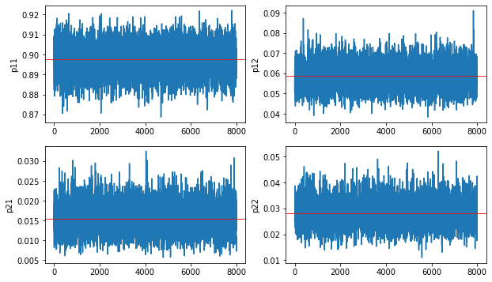

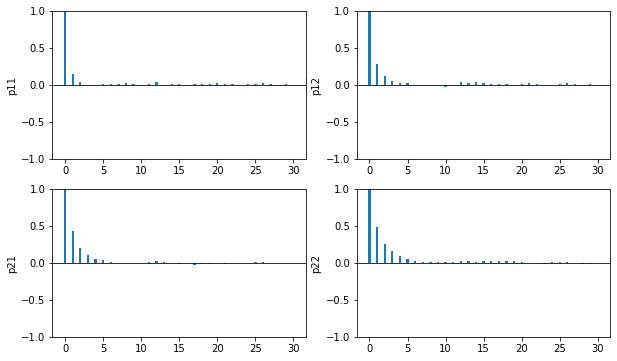

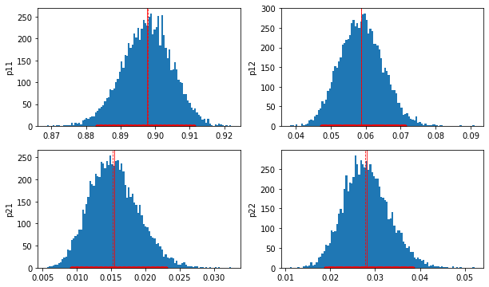

```
param 		 mean 	 var 	 95%CI
p11 		 0.898 	 0.0 	 [0.883, 0.911]
p12 		 0.059 	 0.0 	 [0.047, 0.071]
p21 		 0.015 	 0.0 	 [0.009, 0.023]
p22 		 0.028 	 0.0 	 [0.019, 0.039]
```

```python
gibbs_inst1 = Gibbs_SloveniaData([0.25, 0.25, 0.25, 0.25], [1, 1, 1, 1], 20220406)
gibbs_inst1.generate_samples(10000, print_iter_cycle=2000)
gibbs_diag_inst1 = MCMC_Diag()
gibbs_diag_inst1.set_mc_sample_from_MCMC_instance(gibbs_inst1)
gibbs_diag_inst1.set_variable_names(["p11","p12","p21","p22"])
gibbs_diag_inst1.burnin(2000)

gibbs_diag_inst1.graphic_traceplot_mean=True
gibbs_diag_inst1.show_traceplot((2,2))
gibbs_diag_inst1.show_acf(30, (2,2))
gibbs_diag_inst1.show_hist((2,2))
gibbs_diag_inst1.print_summaries(round=3)
```

I reported traceplots, autocorrelation plots, histograms for $(p_{11},p{12},p_{21},p_{22})$ and brief summary statistics (mean, variance, and 95% (centered) credible interval) from generated samples.

The traceplots look good. We cannot find any evidence that the chain failed to converge to the posterior. Note that Red lines indicate the sample mean. You can find the exact sample mean value at the summary statistics table.

The autocorrelation plots are also good. I could do thinning to reduce autocorelations among near lags, but I would skip it cause they are still diminishing quickly.

On the histograms, red vertical solid and dashed lines indicate sample means and median, respectively. Red horiontal lines are 95% (centered) credible interval. Everything seems good. These histograms can be thought as marginal posterior distributions for the parameters.

Note that the sample variances are not exactly 0 even if the summary table shows us 0. It is a kind of rounding problem... you can find that samples are not degenerated in the traceplots and the histograms.

Let's move on to the parameter that we are interested in. In our model, $p_{11}$ means exactly the fraction of voters who will both attend the plebiscite AND vote in favor of independence. So actually, we already saw the marginal distribution of the fraction through the histogram of $p_{11}$'s posterior. But here, I repeat one more time. Additionally, I calculate ESS, too.

```
p11 ESS: 2072.5506734939027
```

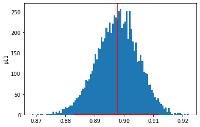

```python
#p11
print("p11 ESS:", gibbs_diag_inst1.effective_sample_size(0))
gibbs_diag_inst1.show_hist_specific_dim(0, True)
```

The mean value of the fraction is 0.898, and it has (posterior) probability 0.95 on [0.883, 0.911].